# Tutorial for PanelPOMP Data Analysis using Pypomp: Supplement 2 for “Mechanistic models for panel data: Analysis of ecological experiments with four interacting species”

#### Parameter Estimation via Panel Iterated Filtering

The `run_level` parameter controls computational intensity. Level 1 provides rapid prototyping, level 2 is the setting used for this document, and level 3 delivers production-quality estimates.

```python
# Np -> evaluation particles, Mp -> MIF particles,
# Np_rep -> evaluation replicates.
algorithmic_params = {
    "Np":     [50,  600, 1000],
    "Np_rep": [ 2,   10,   20],
    "Mp":     [50,  500, 1000],
    "Nmif":   [ 2,  320,  250],
}
Np     = algorithmic_params["Np"][RL]
Np_rep = algorithmic_params["Np_rep"][RL]
Mp     = algorithmic_params["Mp"][RL]
Nmif   = algorithmic_params["Nmif"][RL]
print(f"run_level = {run_level}: Np={Np}, Np_rep={Np_rep}, Mp={Mp}, Nmif={Nmif}")
```

```
run_level = 2: Np=600, Np_rep=10, Mp=500, Nmif=320
```

The random walk standard deviation controls the magnitude of parameter perturbations during iterated filtering. We employ a uniform perturbation intensity across all parameters:

```python
dent_rw_sd = 0.02                       # random-walk sd for the search
n_searches = 10 * N_WORKERS             # ten independent searches per worker

# Every candidate is dispersed log-uniformly over [theta/3, theta*3]; the
# undispersed vector is not retained as a start.
rng = np.random.default_rng(20260723)


def disperse(base, n):
    out = []
    for _ in range(n):
        cand = dict(base)
        for k, v in base.items():
            if v > 0:
                cand[k] = float(np.exp(rng.uniform(np.log(v / 3.0),
                                                   np.log(v * 3.0))))
        out.append(cand)
    return out


parameter_candidates = disperse(shared_parameter, n_searches)

# All eight parameters perturb at dent_rw_sd. sigSn is zero in value, so a
# log-scale perturbation leaves it at zero either way.
srjf_rw_sigmas = {k: dent_rw_sd for k in SRJF_PARAMS}
srjf_rw_sigmas["sigSn"] = 0.0
srjf_rw_sd = pp.RWSigma(sigmas=srjf_rw_sigmas,
                        init_names=[]).geometric_cooling(0.7)
print(f"{n_searches} independent searches, rw_sd = {dent_rw_sd}")
```

```
360 independent searches, rw_sd = 0.02
```

```python
# Pypomp advances all starts in one vectorised call.
ll_all_shared, se_all_shared, theta_all_shared, traces_all_shared = run_searches(
    [shared_theta(c) for c in parameter_candidates],
    srjf_rw_sd, Mp, Nmif, Np, Np_rep, key0=101,
)

# No best run is taken here: `mf` is reassigned by the unit-specific search
# in the next chunk, before `best` is used.
mf = {"ll": ll_all_shared, "se": se_all_shared,
      "theta": theta_all_shared, "traces": traces_all_shared}
print(f"All-shared searches complete: best logLik "
      f"{np.nanmax(ll_all_shared):.2f}")
```

```
All-shared searches complete: best logLik -498.28
```

The unit-specific parameterization partitions the parameter vector into a shared component and a unit-specific component. Because this model contains unit-specific parameters, `block=True` selects marginalized panel iterated filtering (MPIF).

```python
# Starting values come from `parameters`, not from the all-shared search
# result.
specific_names = ["theta_Sn"]
shared_names_uspec = [k for k in SRJF_PARAMS if k not in specific_names]
shared_parameter_uspec = {k: parameters[k] for k in shared_names_uspec}
specific_mat = pd.DataFrame(
    {u: [parameters[p] for p in specific_names] for u in unit_names},
    index=specific_names,
)


def uspec_theta(shared_d, spec_df):
    return {
        "shared": pd.DataFrame({"shared": [shared_d[k] for k in shared_names_uspec]},
                               index=shared_names_uspec),
        "unit_specific": spec_df.copy(deep=True),
    }


# `panelfood` is replaced here by the unit-specific object, which Diagnostic 1
# below filters. Fitting returns a new object and leaves this one at its
# STARTING values, so it must not be reassigned to a fitted panel afterwards.
# One parameter set throughout.
panelfood = pp.PanelPomp(
    Pomp_dict=srjf_pomp_dict,
    theta=pp.PanelParameters(uspec_theta(shared_parameter_uspec, specific_mat)),
)

# sigSn is omitted from the random walk entirely for the unit-specific search.
uspec_rw_sigmas = {k: dent_rw_sd for k in SRJF_PARAMS}
uspec_rw_sigmas["sigSn"] = 0.0
uspec_rw_sd = pp.RWSigma(sigmas=uspec_rw_sigmas,
                         init_names=[]).geometric_cooling(0.7)

uspec_payloads = [uspec_theta(shared_parameter_uspec, specific_mat)] * n_searches
ll_uspec, se_uspec, theta_uspec, traces_uspec = [], [], [], []
for i in range(0, n_searches, SEARCH_BATCH):
    part = uspec_payloads[i:i + SEARCH_BATCH]
    pnl = pp.PanelPomp(Pomp_dict=srjf_pomp_dict, theta=pp.PanelParameters(part))
    pnl.mif(J=Mp, M=Nmif, rw_sd=uspec_rw_sd, block=True,
            key=jax.random.key(303 + i))
    pnl.pfilter(J=Np, reps=Np_rep, key=jax.random.key(404 + i))
    a, b = summarise(pnl.results_history[-1].logLiks.values)
    ll_uspec.extend(a); se_uspec.extend(b)
    theta_uspec.extend(pnl.theta.params(as_list=True))
    t_u = pnl.traces()
    t_u["theta_idx"] = t_u["theta_idx"] + i
    traces_uspec.append(t_u)

# `mf` is reassigned here; `best` and the estimate are then taken from it.
mf = {"ll": np.array(ll_uspec), "se": np.array(se_uspec),
      "theta": theta_uspec, "traces": pd.concat(traces_uspec, ignore_index=True)}
best = int(np.nanargmax(mf["ll"]))
mif_estimate = mf["theta"][best]
pf_loglik_of_mif_estimate = float(mf["ll"][best])
se_of_pf_loglik_of_mif_estimate = float(mf["se"][best])
print(f"Unit-specific MPIF best logLik: {pf_loglik_of_mif_estimate:.2f} "
      f"(SE {se_of_pf_loglik_of_mif_estimate:.2f})")
```

```
Unit-specific MPIF best logLik: -490.02 (SE 0.24)
```

#### Diagnostic 1: Parameter Scaling Verification

To demonstrate the numerical pathologies induced by parameter mis-specification, we compare particle filter performance between the correctly scaled `panelfood` object and the deliberately corrupted `panelfood_wrong` object.

```python
# Both filters use Np and Np_rep from algorithmic_params.
panelfood.pfilter(J=Np, reps=Np_rep, key=jax.random.key(505))
unit_ll_correct = np.asarray(
    panelfood.results_history[-1].logLiks.values)[0]     # (units, reps)
panelfood_wrong.pfilter(J=Np, reps=Np_rep, key=jax.random.key(606))
unit_ll_wrong = np.asarray(
    panelfood_wrong.results_history[-1].logLiks.values)[0]

# Aggregated arithmetically: mean(ll_vec), sd(ll_vec)/sqrt(n).
ll_correct_vec = unit_ll_correct.sum(axis=0)
ll_wrong_vec = unit_ll_wrong.sum(axis=0)
print("Well-scaled parameters:")
print(f"  Panel log-likelihood: {np.mean(ll_correct_vec):.2f} "
      f"(SE {np.std(ll_correct_vec, ddof=1) / np.sqrt(len(ll_correct_vec)):.2f})")
print("\nMis-scaled parameters:")
print(f"  Panel log-likelihood: {np.mean(ll_wrong_vec):.2f} "
      f"(SE {np.std(ll_wrong_vec, ddof=1) / np.sqrt(len(ll_wrong_vec)):.2f})")
print(f"\nLog-likelihood difference: "
      f"{np.mean(ll_correct_vec) - np.mean(ll_wrong_vec):.2f}")
```

```
Well-scaled parameters:
  Panel log-likelihood: -725.73 (SE 2.22)

Mis-scaled parameters:
  Panel log-likelihood: -15000.00 (SE 0.00)

Log-likelihood difference: 14274.27
```

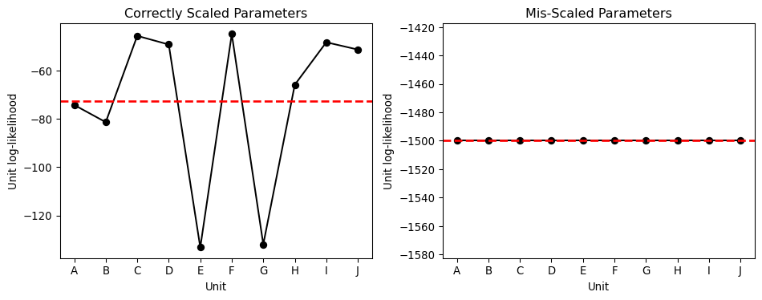

Figure 2: Unit-level log-likelihood contributions under correctly scaled (left) and mis-scaled (right) parameters. Red dashed lines show the mean finite contribution.

```python
# Connected markers, arithmetic row means, -Inf relocated.
fig, axes = plt.subplots(1, 2, figsize=(10, 4))
unit_means_correct = unit_ll_correct.mean(axis=1)
unit_means_wrong = unit_ll_wrong.mean(axis=1)

axes[0].plot(range(1, 11), unit_means_correct, marker="o", linestyle="-",
             color="black")
axes[0].axhline(np.mean(unit_means_correct), color="red", linestyle="--",
                linewidth=2)
axes[0].set_xticks(range(1, 11)); axes[0].set_xticklabels(unit_names)
axes[0].set_xlabel("Unit"); axes[0].set_ylabel("Unit log-likelihood")
axes[0].set_title("Correctly Scaled Parameters")

finite = np.isfinite(unit_means_wrong)
wrong_plot = unit_means_wrong.copy()
if finite.any() and (~finite).any():
    span = np.ptp(unit_means_wrong[finite])
    wrong_plot[~finite] = unit_means_wrong[finite].min() - max(1.0, 0.05 * span)
axes[1].plot(range(1, 11), wrong_plot, marker="o", linestyle="-", color="black")
if finite.any():
    axes[1].axhline(np.mean(unit_means_wrong[finite]), color="red",
                    linestyle="--", linewidth=2)
for i in np.flatnonzero(~finite):
    axes[1].annotate("-Inf", (i + 1, wrong_plot[i]), xytext=(0, 5),
                     textcoords="offset points", ha="center", fontsize=8)
axes[1].set_xticks(range(1, 11)); axes[1].set_xticklabels(unit_names)
axes[1].set_xlabel("Unit"); axes[1].set_ylabel("Unit log-likelihood")
axes[1].set_title("Mis-Scaled Parameters")
fig.tight_layout()
```

#### Diagnostic 2: Evidence for Unit-Specific Parameterization

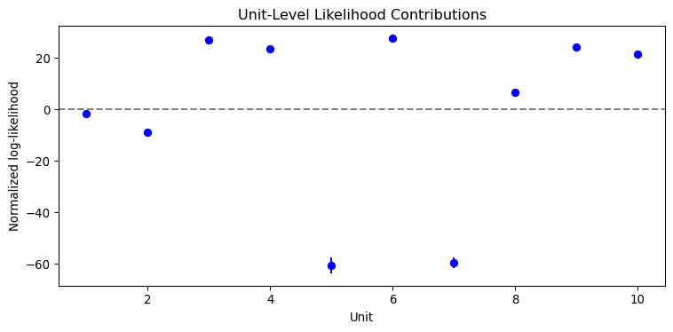

```python
# Arithmetic means, normalised axis, points and segments.
unit_ll_means = unit_ll_correct.mean(axis=1)
unit_ll_ses = unit_ll_correct.std(axis=1, ddof=1) / np.sqrt(Np_rep)
normalized = unit_ll_means - unit_ll_means.mean()
lower = unit_ll_means - 2 * unit_ll_ses - unit_ll_means.mean()
upper = unit_ll_means + 2 * unit_ll_ses - unit_ll_means.mean()

fig, ax = plt.subplots(figsize=(8, 4))
ax.plot(range(1, 11), normalized, "o", color="blue")
ax.vlines(range(1, 11), lower, upper, color="blue")
ax.axhline(0.0, linestyle="--", color="gray")
ax.set_xlabel("Unit"); ax.set_ylabel("Normalized log-likelihood")
ax.set_title("Unit-Level Likelihood Contributions")
fig.tight_layout()
```

```python
p_shared = len(shared_parameter)                                    # 8
aic_shared = 2 * p_shared - 2 * pf_loglik_of_mif_estimate

# A second unit-specific search runs here without blocking, so this
# comparison uses standard PIF.
ll_specific_all, se_specific_all, _, _ = run_searches(
    [uspec_theta(shared_parameter_uspec, specific_mat)] * (2 * N_WORKERS),
    uspec_rw_sd, Mp, Nmif, Np, Np_rep, key0=707,
)
best_specific = int(np.nanargmax(ll_specific_all))
ll_specific = float(ll_specific_all[best_specific])
se_specific = float(se_specific_all[best_specific])

p_specific = len(shared_parameter_uspec) + specific_mat.size            # 7 + 10
aic_specific = 2 * p_specific - 2 * ll_specific

print(f"  All-shared:    p = {p_shared:2d}, logLik = "
      f"{pf_loglik_of_mif_estimate:9.2f}, AIC = {aic_shared:9.2f}")
print(f"  Unit-specific: p = {p_specific:2d}, logLik = {ll_specific:9.2f}, "
      f"AIC = {aic_specific:9.2f}")
print(f"  Delta AIC: {aic_specific - aic_shared:.2f}")
print(f"  Likelihood improvement: {ll_specific - pf_loglik_of_mif_estimate:.2f}")
print(f"  Improvement in SE units: "
      f"{(ll_specific - pf_loglik_of_mif_estimate) / np.sqrt(se_specific**2 + se_of_pf_loglik_of_mif_estimate**2):.2f}")
```

[output not shown]

#### Diagnostic 3: MIF searches visualization

Convergence traces from the independent searches are plotted against iteration number.

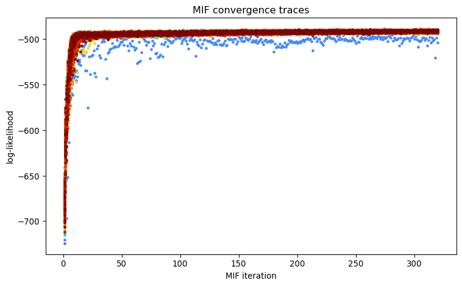

Figure 4: MIF log-likelihood traces across independent searches.

```python
# Traces come from `mf`, that is, from the unit-specific search.
tr = mf["traces"]
tr = tr[(tr["unit"] == "shared") & (tr["method"] == "mif")]
tr = tr[np.isfinite(tr["logLik"])]

fig, ax = plt.subplots(figsize=(8, 5))
cmap = plt.get_cmap("turbo")
idx = sorted(tr["theta_idx"].unique())
# The set is seeded with the best run and then looped from index 2, so run 1
# is dropped and the best run appears twice.
best_trace = best if best in idx else idx[0]
plot_order = [best_trace] + [j for j in idx if j != idx[0]]
for n, j in enumerate(plot_order):
    sub = tr[tr["theta_idx"] == j]
    ax.scatter(sub["iteration"], sub["logLik"], s=6,
               color=cmap(n / max(1, len(plot_order) - 1)))
ax.set_xlabel("MIF iteration"); ax.set_ylabel("log-likelihood")
ax.set_title("MIF convergence traces")
fig.tight_layout()
```

#### Diagnostic 4: Monte Carlo Adjusted Profile

Monte Carlo Adjusted Profile (MCAP) methods provide confidence intervals for situations where the likelihood is evaluated and maximized by Monte Carlo algorithms. A smoothed estimate of the profile likelihood is used to reduce Monte Carlo error, quantify this error, and adjust the confidence intervals accordingly to maintain their coverage.

The following code demonstrates an example about running MCAP analysis on parameter $\theta_{S_n}$.

```
theta_Sn: 400 evaluations, logLik range [-601.1, -498.1], max terminal k_Sn 625.4
MCAP theta_Sn: MLE(log) = -0.2250 -> 0.7985
  95% CI (log): [-0.7458994544658233, 0.42498465688650455]
```

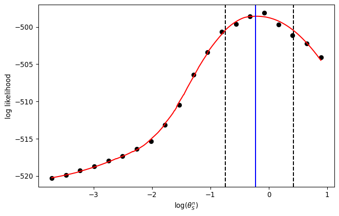

Figure 5: MCAP profile for the adult mortality rate theta_Sn on the log scale. Points are Monte Carlo profile evaluations; the red curve is the smoothed profile, dashed vertical lines are the adjusted 95% confidence limits, and the vertical solid line marks the MCAP estimate.

```python
# A distinct starting vector from the one used for estimation above.
shared_parameter_mcap = {
    "sigF":     1.116997e-05,
    "sigSn":    0.000000e+00,
    "f_Sn":     3.116171e-04,
    "rn":       3.369070e+02,
    "k_Sn":     6.257932e+01,
    "sigJn":    3.073612e-01,
    "theta_Sn": 2.436524e-01,
    "theta_Jn": 3.093602e-03,
}
shared_parameter_mcap = {k: shared_parameter_mcap[k] for k in SRJF_PARAMS}

nprof_sn = 20
_, subset_data_theta_Sn = run_profile("theta_Sn", nprof_sn,
                                      shared_parameter_mcap, seed=1000)
mcap_object_theta_Sn = pp.mcap(
    parameter=subset_data_theta_Sn["log_theta_Sn"].to_numpy(),
    loglik=subset_data_theta_Sn["loglik"].to_numpy(),
    level=0.95, span=0.6, n_grid=1000,
)
theta_Sn_mle = mcap_object_theta_Sn.mle
print(f"MCAP theta_Sn: MLE(log) = {theta_Sn_mle:.4f} -> "
      f"{np.exp(theta_Sn_mle):.4g}")
print(f"  95% CI (log): [{mcap_object_theta_Sn.ci[0]}, "
      f"{mcap_object_theta_Sn.ci[1]}]")
mcap_plot(subset_data_theta_Sn, "theta_Sn", mcap_object_theta_Sn,
          r"$\log(\theta^n_{S})$", "")
```

However, MCAP analysis does not uniformly yield well-defined confidence intervals across all parameters. To illustrate this variability in inferential precision, we examine the profile for the juvenile mortality rate $\theta_{J_n}$.

```
theta_Jn: 2500 evaluations, logLik range [-11363.7, -498.0], max terminal k_Sn 625.6
MCAP theta_Jn: MLE(log) = -8.0810
  80% CI (log): [None, None]
```

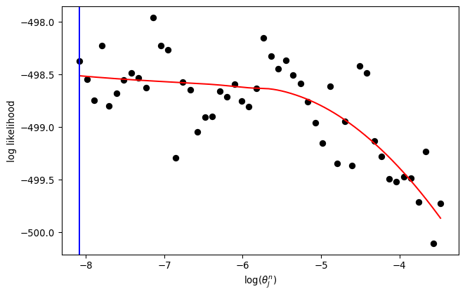

Figure 6: MCAP profile for the juvenile mortality rate theta_Jn on the log scale. The nearly flat profile indicates weak identification over the explored range.

```python
nprof_jn = 50
_, subset_data_theta_Jn = run_profile("theta_Jn", nprof_jn,
                                      shared_parameter_mcap, seed=2000)

# Thin to 51 bins and keep the best point in each before calling mcap.
edges = np.linspace(subset_data_theta_Jn["log_theta_Jn"].min(),
                    subset_data_theta_Jn["log_theta_Jn"].max(), 51)
binned = subset_data_theta_Jn.assign(
    _bin=np.digitize(subset_data_theta_Jn["log_theta_Jn"], edges))
subset_data_theta_Jn = (binned.loc[binned.groupby("_bin")["loglik"].idxmax()]
                              .sort_values("log_theta_Jn")
                              .reset_index(drop=True))

mcap_object_theta_Jn = pp.mcap(
    parameter=subset_data_theta_Jn["log_theta_Jn"].to_numpy(),
    loglik=subset_data_theta_Jn["loglik"].to_numpy(),
    level=0.8, span=0.95, n_grid=1000,
)
print(f"MCAP theta_Jn: MLE(log) = {mcap_object_theta_Jn.mle:.4f}")
print(f"  80% CI (log): [{mcap_object_theta_Jn.ci[0]}, "
      f"{mcap_object_theta_Jn.ci[1]}]")
mcap_plot(subset_data_theta_Jn, "theta_Jn", mcap_object_theta_Jn,
          r"$\log(\theta^n_{J})$", "")
```

The contrast between the profile likelihood shapes reveals fundamental differences in parameter identifiability. For $\theta_{S_n}$ the smoothed profile exhibits pronounced curvature with a well-defined interior maximum, whereas the profile for $\theta_{J_n}$ remains nearly flat across the explored parameter range, characteristic of weak or near-non-identification.

## Section 2: SIRJPF2 Model

### Experimental Design and Data Structure

The treatment consists of $U = 8$ replicated mesocosms, each initialised with both host species in the presence of parasite inoculum, sampled at $N = 10$ time points.

**Show data load and plotting code**

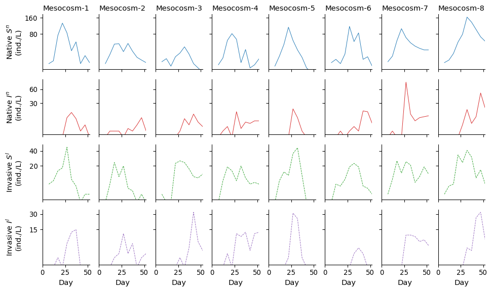

Figure 7: The four adult observation streams used by the SIRJPF2 likelihood across $U = 8$ replicate mesocosms: native susceptible, native infected, invasive susceptible, and invasive infected densities. Square-root y-axes enhance visibility at low densities.

```python
# Load sheet 3 ("both species combined"). The 'dent.ephip ' column has a
# trailing space; strip after read. Column-name and slicing details are in
# quality_reports/audits/DATA_SCHEMA.md.
xls = pd.ExcelFile('../data/Mesocosmdata.xls')
sirjpf_raw = xls.parse('both species combined').iloc[90:170].copy()
sirjpf_raw.columns = sirjpf_raw.columns.str.strip()
sirjpf_raw['day'] = (sirjpf_raw['day'] - 1) * 5 + 7

sirjpf_data = (sirjpf_raw[['rep', 'day', 'dent.adult', 'dent.inf',
                           'lum.adult', 'lum.adult.inf']]
               .sort_values(['rep', 'day'])
               .reset_index(drop=True))

sirjpf_unit_names = ['K', 'L', 'M', 'N', 'O', 'P', 'Q', 'S']
sirjpf_trial_to_mesocosm = {t: f"Mesocosm {i+1}"
                            for i, t in enumerate(sirjpf_unit_names)}
sirjpf_data['Mesocosm'] = sirjpf_data['rep'].map(sirjpf_trial_to_mesocosm)
sirjpf_data['Mesocosm'] = pd.Categorical(
    sirjpf_data['Mesocosm'],
    categories=[f"Mesocosm {i+1}" for i in range(8)],
    ordered=True,
)

# Four-row faceted plot. `sharey='row'` keeps each observation channel on a
# single comparable scale across the eight mesocosms, with y-axis tick labels
# only in the left column.
fig, axes = plt.subplots(
    4, 8,
    sharex=True,
    sharey='row',
    figsize=(10, 6),
    gridspec_kw={'hspace': 0.18, 'wspace': 0.20},
)

obs_cols = ['dent.adult', 'dent.inf', 'lum.adult', 'lum.adult.inf']
row_titles = [r"Native $S^n$",  r"Native $I^n$",
              r"Invasive $S^l$", r"Invasive $I^l$"]
row_colors = [PALETTE["adult"], PALETTE["infected"],
              PALETTE["lum_adult"], PALETTE["lum_inf"]]
row_styles = ['-', '-', '--', '--']

sqrt_scale = dict(value='function', functions=(np.sqrt, np.square))

for j, label in enumerate([f"Mesocosm {i+1}" for i in range(8)]):
    sub = sirjpf_data[sirjpf_data['Mesocosm'] == label]
    for i, col in enumerate(obs_cols):
        ax = axes[i, j]
        ax.plot(sub['day'], sub[col],
                color=row_colors[i], linestyle=row_styles[i], linewidth=0.7)
        ax.set_yscale(**sqrt_scale)
        ax.yaxis.set_major_locator(plt.MaxNLocator(nbins=3))
        ax.set_xlim(0, 52)
        ax.set_xticks([0, 25, 50])
        ax.tick_params(axis='both', labelsize=FONTS["tick"])
        ax.spines['top'].set_visible(False)
        ax.spines['right'].set_visible(False)
        if i == 0:
            ax.set_title(label.replace('Mesocosm ', 'Mesocosm-'),
                         fontsize=FONTS["panel_title"])
        if j == 0:
            ax.set_ylabel(row_titles[i] + '\n(ind./L)',
                          fontsize=FONTS["panel_title"])
        if i == 3:
            ax.set_xlabel('Day', fontsize=FONTS["panel_title"])

fig.align_ylabels(axes[:, 0])
fig.subplots_adjust(left=0.08, right=0.99, top=0.94, bottom=0.08)
```

### Mechanistic Model

#### Model Specification

The SIRJPF2 model extends the SRJF baseline to the full ecological complexity of the Searle et al. (2016) mesocosm experiment: native *D. dentifera* and invasive *D. lumholtzi* compete for a shared algal food resource while both are exposed to *A. monospora*.

#### Biological Mechanisms

Susceptible adults of each species acquire infection through contact with free-living spores, infected adults die at elevated rates and release spores, and both species draw on the same algal resource.

### Parameter Estimation via Panel Iterated Filtering

Marginalized panel iterated filtering (MPIF) is designed for panel models containing unit-specific as well as shared parameters. In Pypomp, `block=True` selects MPIF and changes the resampling treatment of unit-specific parameter particles across panel units. The marginalized-Bayes-map interpretation of MPIF is developed by Wheeler, Abkemeier, and Ionides (2025).

The SIRJPF2 specification used here contains only shared parameters. Consequently, it provides no unit-specific parameter particles for MPIF to marginalize, and a `block=True` versus `block=False` comparison is not informative for this model. We therefore use standard panel iterated filtering for SIRJPF2 and present the MPIF implementation in the unit-specific SRJF example above.

Below we present the complete implementation of standard panel iterated filtering for the SIRJPF2 model.

**Show 8-state SDE simulator with parasite dynamics**

```python
# Eight latent states + four non-negative observables (T_*) + error_count.
SIRJPF_STATENAMES = [
    "Sn", "In", "Jn", "Si", "Ii", "Ji", "F", "P",
    "T_Sn", "T_In", "T_Si", "T_Ii", "error_count",
]


def sirjpf_rproc(X_, theta_, key, covars, t, dt):
    """One Euler-Maruyama step of the SIRJPF2 SDE system."""
    Sn, Jn, In = X_["Sn"], X_["Jn"], X_["In"]
    Si, Ji, Ii = X_["Si"], X_["Ji"], X_["Ii"]
    F, P = X_["F"], X_["P"]
    error_count = X_["error_count"]

    sigSn, sigIn = theta_["sigSn"], theta_["sigIn"]
    sigSi, sigIi = theta_["sigSi"], theta_["sigIi"]
    sigJn, sigJi = theta_["sigJn"], theta_["sigJi"]
    sigF, sigP   = theta_["sigF"],  theta_["sigP"]
    theta_Sn, theta_In = theta_["theta_Sn"], theta_["theta_In"]
    theta_Si, theta_Ii = theta_["theta_Si"], theta_["theta_Ii"]
    theta_Jn, theta_Ji = theta_["theta_Jn"], theta_["theta_Ji"]
    theta_P   = theta_["theta_P"]
    f_Sn, f_Si = theta_["f_Sn"], theta_["f_Si"]
    rn, ri     = theta_["rn"],   theta_["ri"]
    probn, probi = theta_["probn"], theta_["probi"]
    xi         = theta_["xi"]

    # Fixed experimental constants
    delta    = 0.013   # sampling/dilution rate
    mu_food  = 0.37    # algal replenishment
    lambda_J = 0.1     # juvenile maturation rate (both species)

    # Eight independent Gaussian innovations
    keys = jax.random.split(key, 8)
    sqdt = jnp.sqrt(dt)
    noiSn = sigSn * sqdt * jax.random.normal(keys[0])
    noiIn = sigIn * sqdt * jax.random.normal(keys[1])
    noiSi = sigSi * sqdt * jax.random.normal(keys[2])
    noiIi = sigIi * sqdt * jax.random.normal(keys[3])
    noiJn = sigJn * sqdt * jax.random.normal(keys[4])
    noiJi = sigJi * sqdt * jax.random.normal(keys[5])
    noiF  = sigF  * sqdt * jax.random.normal(keys[6])
    noiP  = sigP  * sqdt * jax.random.normal(keys[7])

    # Native species (n)
    Sn_term = (lambda_J * Jn * dt
               - theta_Sn * Sn * dt
               - probn * f_Sn * Sn * P * dt
               - delta * Sn * dt + Sn * noiSn)
    Jn_term = (rn * f_Sn * F * Sn * dt
               - lambda_J * Jn * dt
               - theta_Jn * Jn * dt
               - delta * Jn * dt + Jn * noiJn)
    In_term = (probn * f_Sn * Sn * P * dt
               - theta_In * In * dt
               - delta * In * dt + In * noiIn)

    # Invasive species (l, written `i` in code)
    Si_term = (lambda_J * Ji * dt
               - theta_Si * Si * dt
               - probi * f_Si * Si * P * dt
               - delta * Si * dt + Si * noiSi)
    Ji_term = (ri * f_Si * F * Si * dt
               - lambda_J * Ji * dt
               - theta_Ji * Ji * dt
               - delta * Ji * dt + Ji * noiJi)
    Ii_term = (probi * f_Si * Si * P * dt
               - theta_Ii * Ii * dt
               - delta * Ii * dt + Ii * noiIi)

    # Shared resources
    F_term = (- f_Sn * F * (Sn + xi * In + Jn) * dt
              - f_Si * F * (Si + xi * Ii + Ji) * dt
              - delta * F * dt
              + mu_food * dt + F * noiF)
    P_term = (30.0 * theta_In * In * dt
              + 30.0 * theta_Ii * Ii * dt
              - f_Sn * (Sn + xi * In) * P * dt
              - f_Si * (Si + xi * Ii) * P * dt
              - theta_P * P * dt
              - delta * P * dt + P * noiP)

    Sn_new = Sn + Sn_term
    In_new = In + In_term
    Jn_new = Jn + Jn_term
    Si_new = Si + Si_term
    Ii_new = Ii + Ii_term
    Ji_new = Ji + Ji_term
    F_new  = F  + F_term
    P_new  = P  + P_term

    # Add the inoculum exactly once on the transition beginning at day 4.
    inoculate = (t <= 4.0) & ((t + dt) > 4.0)
    P_new = P_new + jnp.where(inoculate, 25.0, 0.0)

    # Production reset rule with weighted error_count contributions.
    def viol(x, hi):
        return (x < 0.0) | (x > hi)

    eps = 0.0
    eps += jnp.where(viol(Sn_new, 1e5), 1.0,    0.0)
    eps += jnp.where(viol(Si_new, 1e5), 1.0e6,  0.0)
    eps += jnp.where(viol(F_new,  1e20), 1.0e3, 0.0)
    eps += jnp.where(viol(In_new, 1e5), 1.0e-3, 0.0)
    eps += jnp.where(viol(Ii_new, 1e5), 1.0e-9, 0.0)
    eps += jnp.where(viol(Jn_new, 1e5), 1.0e-3, 0.0)
    eps += jnp.where(viol(Ji_new, 1e5), 1.0e-9, 0.0)
    eps += jnp.where(viol(P_new,  1e20) & (t > 3.9), 1.0e-6, 0.0)

    Sn_new = jnp.where(viol(Sn_new, 1e5), 0.0, Sn_new)
    In_new = jnp.where(viol(In_new, 1e5), 0.0, In_new)
    Jn_new = jnp.where(viol(Jn_new, 1e5), 0.0, Jn_new)
    Si_new = jnp.where(viol(Si_new, 1e5), 0.0, Si_new)
    Ii_new = jnp.where(viol(Ii_new, 1e5), 0.0, Ii_new)
    Ji_new = jnp.where(viol(Ji_new, 1e5), 0.0, Ji_new)
    F_new  = jnp.where(viol(F_new, 1e20), 0.0, F_new)
    P_new  = jnp.where(viol(P_new, 1e20) & (t > 3.9), 0.0, P_new)

    return {
        "Sn": Sn_new, "In": In_new, "Jn": Jn_new,
        "Si": Si_new, "Ii": Ii_new, "Ji": Ji_new,
        "F":  F_new,  "P":  P_new,
        "T_Sn": jnp.abs(Sn_new), "T_In": jnp.abs(In_new),
        "T_Si": jnp.abs(Si_new), "T_Ii": jnp.abs(Ii_new),
        "error_count": error_count + eps,
    }
```

**Show initial-state specification**

```python
def sirjpf_rinit(theta_, key, covars, t0):
    """Deterministic initial conditions; t0 = 1."""
    return {
        "Sn":          jnp.array(2.333),   # 35 / 15 L
        "In":          jnp.array(0.0),
        "Jn":          jnp.array(0.0),
        "Si":          jnp.array(0.667),   # 10 / 15 L
        "Ii":          jnp.array(0.0),
        "Ji":          jnp.array(0.0),
        "F":           jnp.array(16.667),  # 250e6 cells / 15 L
        "P":           jnp.array(0.0),
        "T_Sn":        jnp.array(0.0),
        "T_In":        jnp.array(0.0),
        "T_Si":        jnp.array(0.0),
        "T_Ii":        jnp.array(0.0),
        "error_count": jnp.array(0.0),
    }
```

**Show 4-D negative-binomial log-density**

```python
def _sirjpf_nb_logpmf(y, mu, size):
    mu   = jnp.maximum(mu,   1e-10)
    size = jnp.maximum(size, 1e-10)
    return (jax.scipy.special.gammaln(y + size)
            - jax.scipy.special.gammaln(size)
            - jax.scipy.special.gammaln(y + 1.0)
            + size * jnp.log(size / (size + mu))
            + y    * jnp.log(mu   / (size + mu)))


def sirjpf_dmeas(Y_, X_, theta_, covars, t):
    """4-D NB log-pmf: dent.adult, dent.inf, lum.adult, lum.adult.inf."""
    error_count = X_["error_count"]
    ll_dent_adult = _sirjpf_nb_logpmf(Y_["dentadult"], X_["T_Sn"], theta_["k_Sn"])
    ll_dent_inf   = _sirjpf_nb_logpmf(Y_["dentinf"],   X_["T_In"], theta_["k_In"])
    ll_lum_adult  = _sirjpf_nb_logpmf(Y_["lumadult"],  X_["T_Si"], theta_["k_Si"])
    ll_lum_inf    = _sirjpf_nb_logpmf(Y_["luminf"],    X_["T_Ii"], theta_["k_Ii"])
    ll = ll_dent_adult + ll_dent_inf + ll_lum_adult + ll_lum_inf
    # Soft penalty when the simulator violated a state bound during the step.
    return jnp.where(error_count > 0.0, -150.0, ll)
```

**Show 4-D measurement sampler**

```python
def _sirjpf_nb_sample(key, mu, size):
    mu   = jnp.maximum(mu,   1e-10)
    size = jnp.maximum(size, 1e-10)
    k1, k2 = jax.random.split(key)
    scale = mu / size
    g = jax.random.gamma(k1, size) * scale
    return jax.random.poisson(k2, g)


def sirjpf_rmeas(X_, theta_, key, covars, t):
    """Simulate the four-dimensional NB observation."""
    keys = jax.random.split(key, 4)
    y_dent_adult = _sirjpf_nb_sample(keys[0], X_["T_Sn"], theta_["k_Sn"])
    y_dent_inf   = _sirjpf_nb_sample(keys[1], X_["T_In"], theta_["k_In"])
    y_lum_adult  = _sirjpf_nb_sample(keys[2], X_["T_Si"], theta_["k_Si"])
    y_lum_inf    = _sirjpf_nb_sample(keys[3], X_["T_Ii"], theta_["k_Ii"])
    return jnp.array(
        [y_dent_adult, y_dent_inf, y_lum_adult, y_lum_inf], dtype=float,
    )
```

**Show parameter transformations**

```python
# Every positive parameter is log-transformed. sigSn and sigSi are fixed at 0
# in MIF (rw_sd = 0) and therefore pass through to_est / from_est unchanged.
_SIRJPF_LOG_PARAMS = (
    "rn", "ri", "f_Sn", "f_Si", "probn", "probi", "xi",
    "theta_Sn", "theta_Si", "theta_In", "theta_Ii",
    "theta_Jn", "theta_Ji", "theta_P",
    "sigIn", "sigIi", "sigJn", "sigJi", "sigF", "sigP",
    "k_Sn", "k_Si", "k_In", "k_Ii",
)


def sirjpf_to_est(theta):
    """Natural -> estimation scale."""
    out = {**theta}
    for n in _SIRJPF_LOG_PARAMS:
        out[n] = jnp.log(jnp.maximum(theta[n], 1e-30))
    out["sigSn"] = theta["sigSn"]
    out["sigSi"] = theta["sigSi"]
    return out


def sirjpf_from_est(theta):
    """Estimation -> natural scale."""
    out = {**theta}
    for n in _SIRJPF_LOG_PARAMS:
        out[n] = jnp.exp(theta[n])
    out["sigSn"] = theta["sigSn"]
    out["sigSi"] = theta["sigSi"]
    return out


sirjpf_par_trans = pp.ParTrans(to_est=sirjpf_to_est, from_est=sirjpf_from_est)
```

```python
# Shared SIRJPF2 starting vector.
sirjpf_shared_theta = {
    "ri":       1.307600e+04,  "rn":       5.904676e+01,
    "f_Si":     1.838259e-05,  "f_Sn":     1.105668e-03,
    "probi":    3.110083e+01,  "probn":    2.565626e-01,
    "xi":       2.865620e+01,
    "theta_Sn": 1.479834e-01,  "theta_Si": 3.186040e-02,
    "theta_Ii": 3.531879e-01,  "theta_In": 5.489315e-01,
    "theta_P":  2.024991e-02,
    "theta_Ji": 1.299562e-04,  "theta_Jn": 1.532613e-04,
    "sigSn":    0.0,           "sigSi":    0.0,
    "sigIn":    3.063207e-04,  "sigIi":    2.208698e-02,
    "sigJi":    2.727418e-01,  "sigJn":    2.836891e-01,
    "sigF":     1.551729e-01,  "sigP":     2.385890e-01,
    "k_Ii":     1.241092e+00,  "k_In":     1.005756e+00,
    "k_Si":     4.715556e+00,  "k_Sn":     4.282648e+00,
}

sirjpf_unit_names_full = ['K', 'L', 'M', 'N', 'O', 'P', 'Q', 'S']
t0_sirjpf = 1.0  # 6-day pre-observation window; parasite inoculum at t = 4.

# Build one Pomp object per replicate.
sirjpf_pomp_dict = {}
for u in sirjpf_unit_names_full:
    sub = (sirjpf_data[sirjpf_data['rep'] == u]
           [['day', 'dent.adult', 'dent.inf', 'lum.adult', 'lum.adult.inf']]
           .rename(columns={
               'dent.adult':     'dentadult',
               'dent.inf':       'dentinf',
               'lum.adult':      'lumadult',
               'lum.adult.inf':  'luminf',
           })
           .sort_values('day'))
    ys_u = (sub.set_index('day')
              [['dentadult', 'dentinf', 'lumadult', 'luminf']]
              .astype(float))

    sirjpf_pomp_dict[u] = pp.Pomp(
        ys=ys_u,
        theta=pp.PompParameters(sirjpf_shared_theta),
        statenames=SIRJPF_STATENAMES,
        t0=t0_sirjpf,
        rinit=sirjpf_rinit,
        rproc=sirjpf_rproc,
        dmeas=sirjpf_dmeas,
        rmeas=sirjpf_rmeas,
        par_trans=sirjpf_par_trans,
        dt=0.25,
        accumvars=("error_count",),
    )

# All-shared parameterisation.
sirjpf_shared_df = pd.DataFrame(
    {"shared": list(sirjpf_shared_theta.values())},
    index=list(sirjpf_shared_theta.keys()),
)
sirjpf_unit_specific_df = pd.DataFrame(
    index=[], columns=sirjpf_unit_names_full,
)
panelfood_sirjpf = pp.PanelPomp(
    Pomp_dict=sirjpf_pomp_dict,
    theta=pp.PanelParameters(
        {"shared": sirjpf_shared_df,
         "unit_specific": sirjpf_unit_specific_df}
    ),
)
print(f"Number of units: {len(panelfood_sirjpf.unit_objects)}")
print(f"Shared parameters: {len(panelfood_sirjpf.canonical_shared_param_names)}")
```

```
Number of units: 8
Shared parameters: 26
```

```python
# Section 2 uses its own algorithmic settings.
algorithmic_params_sirjpf = {
    "Np":     [50,  500, 1000],
    "Np_rep": [ 2,   10,   10],
    "Mp":     [50,  500, 1000],
    "Nmif":   [ 2,  300,  250],
}
Np_s     = algorithmic_params_sirjpf["Np"][RL]
Np_rep_s = algorithmic_params_sirjpf["Np_rep"][RL]
Mp_s     = algorithmic_params_sirjpf["Mp"][RL]
Nmif_s   = algorithmic_params_sirjpf["Nmif"][RL]

dent_rw_sd_sirjpf = 0.05                       # random-walk sd for Section 2
n_searches_sirjpf = 2 * N_WORKERS              # two searches per worker

# One identical start is replicated; the runs differ only through the RNG.
sirjpf_rw_sigmas = {k: dent_rw_sd_sirjpf for k in sirjpf_shared_theta}
sirjpf_rw_sigmas["sigSn"] = 0.0
sirjpf_rw_sigmas["sigSi"] = 0.0
sirjpf_rw_sd = pp.RWSigma(sigmas=sirjpf_rw_sigmas,
                          init_names=[]).geometric_cooling(0.7)

panelfood_sirjpf = pp.PanelPomp(
    Pomp_dict=sirjpf_pomp_dict,
    theta=pp.PanelParameters(
        [{"shared": sirjpf_shared_df.copy(deep=True),
          "unit_specific": sirjpf_unit_specific_df.copy(deep=True)}]
        * n_searches_sirjpf),
)
panelfood_sirjpf.mif(J=Mp_s, M=Nmif_s, rw_sd=sirjpf_rw_sd, block=False,
                     key=jax.random.key(1601))
panelfood_sirjpf.pfilter(J=Np_s, reps=Np_rep_s, key=jax.random.key(1602))
lls_sirjpf2, ses_sirjpf2 = summarise(
    panelfood_sirjpf.results_history[-1].logLiks.values)

best_sirjpf2 = int(np.nanargmax(lls_sirjpf2))
mif_estimate_sirjpf2 = panelfood_sirjpf.theta.params(as_list=True)[best_sirjpf2]
pf_loglik_of_mif_estimate_sirjpf2 = float(lls_sirjpf2[best_sirjpf2])
se_of_pf_loglik_sirjpf2 = float(ses_sirjpf2[best_sirjpf2])
print(f"SIRJPF2 best logLik: {pf_loglik_of_mif_estimate_sirjpf2:.2f} "
      f"(SE {se_of_pf_loglik_sirjpf2:.2f}) over {n_searches_sirjpf} searches")
```

```
SIRJPF2 best logLik: -884.83 (SE 0.34) over 72 searches
```

The SIRJPF2 searches use standard PIF because the fitted specification contains only shared parameters. The terminal parameter estimates are evaluated by replicated particle filters, and the search with the largest estimated panel log-likelihood is retained for subsequent inference.

Akaike, H. 1974. “A New Look at the Statistical Model Identification.” *IEEE Transactions on Automatic Control* 19 (6): 716–23.

Bretó, Carles, Edward L. Ionides, and Aaron A. King. 2020. “Panel Data Analysis via Mechanistic Models.” *Journal of the American Statistical Association* 115 (531): 1178–88. https://doi.org/10.1080/01621459.2019.1604367.

Ionides, Edward L, Carles Breto, Joonha Park, Richard A Smith, and Aaron A King. 2017. “Monte Carlo Profile Confidence Intervals for Dynamic Systems.” *Journal of the Royal Society Interface* 14: 1–10.

Lachance, Marc-André, Carla E. Cáceres, Molly J. Fredericks, Meghan A. Duffy, and Tara E. Stewart Merrill. 2025. “Reviving Élie Metschnikoff’s *Monospora*: The Obligately Parasitic Yeast *Australozyma Monospora* Sp. Nov.” *FEMS Yeast Research* 25: foaf041. https://doi.org/10.1093/femsyr/foaf041.

Ning, N., E. L. Ionides, and Y. Ritov. 2021. “Scalable Monte Carlo Inference and Rescaled Local Asymptotic Normality.” *Bernoulli* 27: 2532–55.

Searle, Catherine L, Michael H Cortez, Katherine K Hunsberger, Dylan C Grippi, Isabella A Oleksy, Clara L Shaw, Solanus B de la Serna, Chloe L Lash, Kailash L Dhir, and Meghan A Duffy. 2016. “Population Density, Not Host Competence, Drives Patterns of Disease in an Invaded Community.” *The American Naturalist* 188 (5): 554–66. https://doi.org/10.1086/688402.

Wheeler, Jesse, Aaron J. Abkemeier, and Edward L. Ionides. 2025. “Iterating Marginalized Bayes Maps for Likelihood Maximization.” *In Preparation*.